# Anomaly Detection Using Image Classification

### The most important task of my day jobs working in a IC design company

- To root-cause all the manufacturing bugs or failure so to productionize

### AlSO! It is an extreme frustration

- A manufacturing bug involves way more factors than a software bug
- A solution always takes serveral iterations(days~) before being justified

So... it comes to me if I can **Automate** to root cause an issue

And... as most engineers always do, I **Google Search**

And... I found **Convolutional Neural Network (CNN)** come to rescue

[PyTorch](https://pytorch.org/) -> [Fastai](https://www.fast.ai/) -> Fastai MOOC international fellowship

- with pytorch 1.0, I can **seamlessly** transitions between **research prototyping** and **production deployment**
- fastai is a **flexible** architecture to add state-of-the-art techniques
- both pytorch and fastai community **grows rapidly**

As always, let's get started with **Data Pipeline**

```python
from fastai import *
from fastai.vision import *
from fastai.callbacks import *
```

```python
tfms = get_transforms(do_flip=False, max_zoom=1)
```

```python
src = (ImageItemList.from_folder(PATH)
       .random_split_by_pct()
       .label_from_folder())
```

```python
data = (src.transform(tfms=tfms, size=224)
        .databunch(bs=64)
        .normalize(imagenet_stats))
```

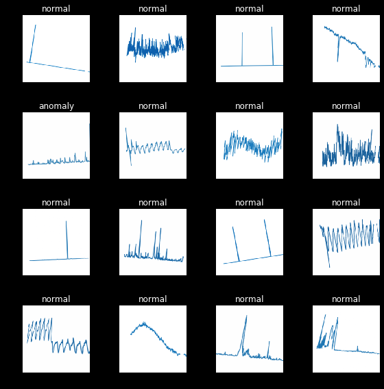

```python
data.show_batch(rows=4, figsize=(8,8))
```

```python
data
```

```
ImageDataBunch;

Train: LabelList
y: CategoryList (508 items)
[Category anomaly, Category anomaly, Category anomaly, Category anomaly, Category anomaly]...
Path: /home/jupyter/.fastai/data/anomaly
x: ImageItemList (508 items)
[Image (3, 224, 224), Image (3, 224, 224), Image (3, 224, 224), Image (3, 224, 224), Image (3, 224, 224)]...
Path: /home/jupyter/.fastai/data/anomaly;

Valid: LabelList
y: CategoryList (126 items)
[Category anomaly, Category normal, Category normal, Category normal, Category anomaly]...
Path: /home/jupyter/.fastai/data/anomaly
x: ImageItemList (126 items)
[Image (3, 224, 224), Image (3, 224, 224), Image (3, 224, 224), Image (3, 224, 224), Image (3, 224, 224)]...
Path: /home/jupyter/.fastai/data/anomaly;

Test: None
```

### Technique #1: Transfer Learning

As shown 2 slides ago, we only has **508** and **126** items for training set and validation set respectively. With such small amount of data, I am going to use a *pre-trained* [*resnet34*](https://arxiv.org/pdf/1512.03385.pdf) as my backbone and on top of it, we pile three fully connected layers with **dropout** and **batch norm**.

```python
learn = create_cnn(data, models.resnet34, metrics=error_rate)
```

### Technique #2: Learning Rate Finder

```python
learn.lr_find()
```

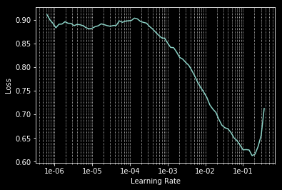

```python
learn.recorder.plot()
plt.gca().grid(axis='x', which='both', linestyle=':')
```

So...here I select `1e-2` as my learning rate

### Technique #3: [1-Cycle Policy](https://arxiv.org/abs/1708.07120)

[figure not shown]

```python
learn.recorder.plot_lr(show_moms=True)
```

```python
learn.fit_one_cycle(10, 1e-2)
```

Total time: 00:27

[output not shown]

Result interpretation...

[figure not shown]

```python
interp.plot_confusion_matrix(figsize=(8,8), dpi=60)
```

### Technique #4: Discriminative Learning Rates

[figure not shown]

Futher training...

```python
learn.unfreeze()
```

```python
learn.fit_one_cycle(10, slice(1e-4))
```

Total time: 00:27

| epoch | train_loss | valid_loss | error_rate |
| --- | --- | --- | --- |
| 1 | 0.081575 | 0.092502 | 0.039683 |
| 2 | 0.071382 | 0.092599 | 0.039683 |
| 3 | 0.058237 | 0.094887 | 0.039683 |
| 4 | 0.052389 | 0.082674 | 0.031746 |
| 5 | 0.052574 | 0.085728 | 0.031746 |
| 6 | 0.060251 | 0.093697 | 0.039683 |
| 7 | 0.059458 | 0.097919 | 0.031746 |
| 8 | 0.061505 | 0.098460 | 0.039683 |
| 9 | 0.062167 | 0.104274 | 0.039683 |
| 10 | 0.061280 | 0.102488 | 0.039683 |

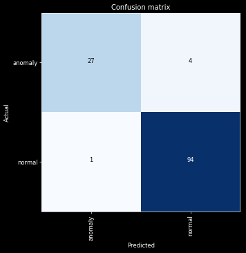

```python
interp.plot_confusion_matrix(figsize=(6,6), dpi=60)
```

### Technique #5: Representability

```python
tfms = get_transforms(do_flip=False, flip_vert=False, max_rotate=0.0,
                      max_lighting=0.0, max_warp=0.0, p_affine=0.0)
```

```python
pat = r"(\d*)-\d*-\d*.png$"
src = (ImageItemList.from_folder(PATH)
       .split_by_files(valid_fns)
       .label_from_re(pat=pat))
```

```python
data = (src.transform(tfms=tfms, size=224)
        .databunch(bs=64)
        .normalize(imagenet_stats))
```

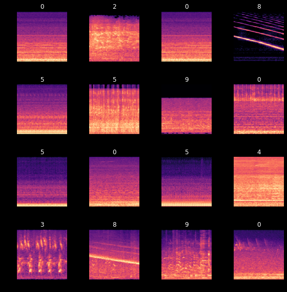

```python
data.show_batch(rows=4, figsize=(8,8))
```

### Technique #6: Pre-train with External Dataset

The rule of thumb here is to find any open dataset that is similar to our target dataset

1. [FreeSound](https://www.freesound.org)
2. [Audioset](https://research.google.com/audioset/)

Repeat the previous techniques...

Final Result: **79.6%**

*In a sensibly organised society, if you improve productivity, there is room for everybody to benefit*